# Regional Housing Framework

Vacant lots analysis for Arlington County

Library: RegHsg

Project: Regional Housing Framework

Author: Sarah Strochak

Version: R 3.5.1, RStudio 1.1.423

Last updated August 21, 2019

Environment: Local Windows session (desktop)

## Description

1. Merge cleaned parcel data with zoning code data.
2. Calculate how many units are allowed one each parcel.
3. Filter out and sum for vacant lots.

## Set-up

Load libraries and functions

```r
library(tidyverse)
library(urbnthemes)
library(sf)

set_urbn_defaults("print")

source("../../Macros/read-arlington.R")
```

Create directory for data exports

```r
if (!dir.exists("../../Data")) {
  dir.create("../../Data")
}

if (!dir.exists("L:/Libraries/RegHsg/Prog/Tables")) {
  dir.create("L:/Libraries/RegHsg/Prog/Tables")
}
```

Set FIPS code and filepath name

```r
currentfips <- "51013"
filepath <- "arlington"
```

Load in cleaned Black Knight data for Arlington County.

```r
if (!exists("jur")) {
  jur <- read_arlington()
} else {
  warning(filepath, " data already read in")
}
```

## Clean zoning code information

### Move file

First- **manually** move file from Box to the `zoning-codes` directory in the `Doc` folder on the L drive. Name file accordingly: “jursidiction-zoning-code.csv”

### Read file

Read in zoning code, rename variables so that they are machine readable

```r
if (!file.exists(paste0("L:/Libraries/RegHsg/Doc/zoning-codes/",
                              filepath,
                              "-zoning-code.csv"))) {

  stop("Move zoning file for jurisdiction to L:/Libraries/RegHsg/Doc/zoning-codes directory")
}
```

```r
z <- cols(
  Code = col_character(),
  `District Type` = col_character(),
  `Type of Dwelling` = col_character(),
  `Site Area` = col_number(),
  `Lot area` = col_number(),
  `Lot area per dwelling unit (sq. ft.) (minimum)` = col_number(),
  `Lot Width (average minimum, ft)` = col_character(),
  `Height (ft)` = col_double(),
  `Height (stories)` = col_double(),
  `Lot coverage maximum` = col_number(),
  `Floor area minimum` = col_double(),
  `Maximum Density of Floor-Area-Ratio (FAR)` = col_character(),
  `Setbacks (centerline)` = col_character(),
  `Setbacks (right of way line)` = col_double(),
  `Front/Side yard (ft)` = col_double(),
  `Side yard (both sides: minimum percent of required width)` = col_number(),
  Frontage = col_double(),
  Comments = col_character()
)

zoningcode <- read_csv(paste0("L:/Libraries/RegHsg/Doc/zoning-codes/",
                              filepath,
                              "-zoning-code.csv"),
                       col_types = z)

names(zoningcode) <-
  c("zoning_code", "district_type", "dwelling_type",
    "site_area", "lot_area_min", "lotarea_per_unit",
    "lot_width", "height_ft", "height_stories",
    "lot_coverage_max", "floor_area_min", "far_max",
    "setbacks_center", "setbacks_row",
    "front_side_yard", "side_yard", "frontage", "comments")

# fix variables read in as whole numbers (should be percent)
zoningcode <- zoningcode %>%
  mutate_at(vars(lot_coverage_max, side_yard),
            ~ . / 100)
rm(z)
```

### Creating dwelling_type hierarchy

For the vacant lots analysis, we want to determine the `dwelling_type` that allows for the most dense construction for that zone.

First, we look at all the options, and filter out all the observations marked as “other”, since we cannot be sure what property type that refers to. We will also filter out categories that are dependent on adjacent lot lines.

```r
zoningcode %>%
  count(dwelling_type) %>%
  knitr::kable()
```

| dwelling_type | n |
| --- | --- |
| All | 1 |
| All Other | 32 |
| Duplex | 7 |
| Duplex; share a lot line with RA, C, or M | 1 |
| Multiple-family | 9 |
| One Family Dwelling | 30 |
| Other Residential | 1 |
| Semi-detached | 7 |
| Semi-detatched; share a lot line with RA, C, or M | 1 |
| Townhouse | 7 |

Count the number of unique zoning codes to make sure we won’t get rid of any codes entirely.

```r
length(unique(zoningcode$zoning_code))
```

```
## [1] 34
```

Filter out dwelling_types of “All”, “All Other”, and those that are dependent on a shared boundary.

```r
zoningcode1 <- zoningcode %>%
  group_by(zoning_code) %>%
  filter(!(dwelling_type %in% c("All",
                                "All Other",
                                "Duplex; share a lot line with RA, C, or M",
                                "Semi-detatched; share a lot line with RA, C, or M")
           & n() > 1)) %>%
  ungroup()
```

Make sure we did not lose any zoning codes entirely.

```r
stopifnot(length(unique(zoningcode$zoning_code))
          == length(unique(zoningcode1$zoning_code)))
```

Since the variables are not always comparable, the following order, from most to least dense, applies:

1. Multiple-family
2. Townhouse
3. Semi-detached
4. Duplex
5. Other Residential
6. One Family Dwelling

### Create factor variable

To use this hierarchy, we transform the `dwelling_type` variable into a factor, assign the factors to the appropriate level, (1-6, as listed above). We will also create a designation for dwelling types that are restricted to a certain amount of units (one unit for “One Family Dwelling” and one for two units for “Duplex”).

**NOTE** This will be VERY jurisdiction specific.

**NOTE** If there are no one or two unit limitations, still make the variable and set them all equal to zero. This allows the functionality of the calculation to be more uniform across counties.

```r
zoningcode1 <- zoningcode1 %>%
  mutate(dwelling_type = factor(dwelling_type,
                                levels = c("Multiple-family",
                                           "Townhouse",
                                           "Semi-detached",
                                           "Duplex",
                                           "Other Residential",
                                           "One Family Dwelling")),
         one_unit_flag = ifelse(dwelling_type == "One Family Dwelling",
                                1,
                                0),
         two_unit_flag = ifelse(dwelling_type == "Duplex",
                                1,
                                0))
```

## Clean parcel data

See how many lots have missing key variables

```r
jur %>%
  mutate(num = NA) %>%
  group_by(category_detail) %>%
  summarize_at(vars(propaddress, lotsize_sf, zoning, num),
               ~ sum(is.na(.))) %>%
  mutate_at(vars(propaddress, lotsize_sf, zoning),
            .funs = funs(percent = scales::percent(. / num))) %>%
  knitr::kable(caption = "Number and percent of missing values")
```

Number and percent of missing values

| category_detail | propaddress | lotsize_sf | zoning | num | propaddress_percent | lotsize_sf_percent | zoning_percent |
| --- | --- | --- | --- | --- | --- | --- | --- |
| apartment | 23 | 0 | 8 | 618 | 3.7% | 0.0% | 1.3% |
| commercial | 75 | 0 | 18 | 1081 | 6.9% | 0.0% | 1.7% |
| condo | 6 | 2 | 4 | 1730 | 0.3% | 0.1% | 0.2% |
| duplex | 0 | 0 | 1 | 271 | 0.0% | 0.0% | 0.4% |
| office | 2 | 0 | 6 | 156 | 1.3% | 0.0% | 3.8% |
| sf attached | 0 | 0 | 0 | 4129 | 0.0% | 0.0% | 0.0% |
| sf detached | 13 | 0 | 41 | 27494 | 0.0% | 0.0% | 0.1% |
| townhouse | 0 | 0 | 24 | 4292 | 0.0% | 0.0% | 0.6% |
| vacant commercial | 583 | 1 | 8 | 747 | 78.0% | 0.1% | 1.1% |
| vacant exempt | 54 | 34 | 34 | 69 | 78.3% | 49.3% | 49.3% |
| vacant light industrial | 3 | 0 | 0 | 4 | 75.0% | 0.0% | 0.0% |
| vacant mf | 68 | 0 | 3 | 101 | 67.3% | 0.0% | 3.0% |
| vacant office | 64 | 1 | 4 | 95 | 67.4% | 1.1% | 4.2% |
| vacant residential | 285 | 20 | 80 | 518 | 55.0% | 3.9% | 15.4% |
| vacant sf | 553 | 2 | 2 | 741 | 74.6% | 0.3% | 0.3% |

### Missing lot size

We will fill in the missing lot size, when we can, with the area of the lot, obtained from the parcel shapefile in the precleaning step. If that is also missing, we use the lot size variables from the property file. All variables are in square feet.

```r
jur1 <- jur %>%
  mutate(arc_lotsize_sf = lotsize_sf, # archive the original lot size variable
         lotsize_sf = ifelse(is.na(lotsize_sf),
                             parcel_area,
                             lotsize_sf),
         lotsize_sf = ifelse(is.na(lotsize_sf),
                             lotsize_prop,
                             lotsize_sf))
```

See how many were filled in

```r
sum(is.na(jur$lotsize_sf)) - sum(is.na(jur1$lotsize_sf))
```

```
## [1] 0
```

### Assessment values

The difference between the land value, improvement value, and total value can help us determine if lots are really vacant.

```r
jur1 %>%
  group_by(category_detail) %>%
  summarize(nprops = n(),
            imp_zero = sum(assessedimprovementvalue == 0, na.rm = TRUE),
            imp_na = sum(is.na(assessedimprovementvalue))) %>%
  mutate(imp_none = imp_zero + imp_na,
         percent_none = imp_none / nprops) %>%
  knitr::kable()
```

| category_detail | nprops | imp_zero | imp_na | imp_none | percent_none |
| --- | --- | --- | --- | --- | --- |
| apartment | 618 | 0 | 0 | 0 | 0.0000000 |
| commercial | 1081 | 0 | 0 | 0 | 0.0000000 |
| condo | 1730 | 0 | 0 | 0 | 0.0000000 |
| duplex | 271 | 0 | 0 | 0 | 0.0000000 |
| office | 156 | 0 | 0 | 0 | 0.0000000 |
| sf attached | 4129 | 0 | 0 | 0 | 0.0000000 |
| sf detached | 27494 | 0 | 0 | 0 | 0.0000000 |
| townhouse | 4292 | 0 | 0 | 0 | 0.0000000 |
| vacant commercial | 747 | 743 | 0 | 743 | 0.9946452 |
| vacant exempt | 69 | 69 | 0 | 69 | 1.0000000 |
| vacant light industrial | 4 | 4 | 0 | 4 | 1.0000000 |
| vacant mf | 101 | 100 | 0 | 100 | 0.9900990 |
| vacant office | 95 | 92 | 0 | 92 | 0.9684211 |
| vacant residential | 518 | 512 | 0 | 512 | 0.9884170 |
| vacant sf | 741 | 704 | 0 | 704 | 0.9500675 |

Most of the vacant properties have either a 0 or a missing value for the improvement value, which is what we would expect. We can take a closer look at properties that have a non-zero value and decide if we need to re-categorize them as not really vacant- if there is a structure there, we do not want to include it in this calculation.

```r
jur1 %>%
  filter(category == "vacant",
         assessedimprovementvalue > 0,
         !is.na(assessedimprovementvalue)) %>%
  mutate(p_total = assessedimprovementvalue / totalassessedvalue) %>%
  group_by(category_detail) %>%
  summarize(n = n(),
            mean = mean(assessedimprovementvalue),
            median = median(assessedimprovementvalue),
            min = min(assessedimprovementvalue),
            max = max(assessedimprovementvalue),
            p_total = median(p_total)) %>%
  knitr::kable()
```

| category_detail | n | mean | median | min | max | p_total |
| --- | --- | --- | --- | --- | --- | --- |
| vacant commercial | 4 | 1272150.0 | 278750 | 1000 | 4530100 | 0.1308071 |
| vacant mf | 1 | 143627200.0 | 143627200 | 143627200 | 143627200 | 0.8656408 |
| vacant office | 3 | 86444133.3 | 81972200 | 120400 | 177239800 | 0.8426254 |
| vacant residential | 6 | 17828066.7 | 2586100 | 65700 | 94416300 | 0.5344781 |
| vacant sf | 37 | 568635.1 | 369100 | 86500 | 2737500 | 0.2819811 |

Look at the distribution of improved value as a percent of total value.

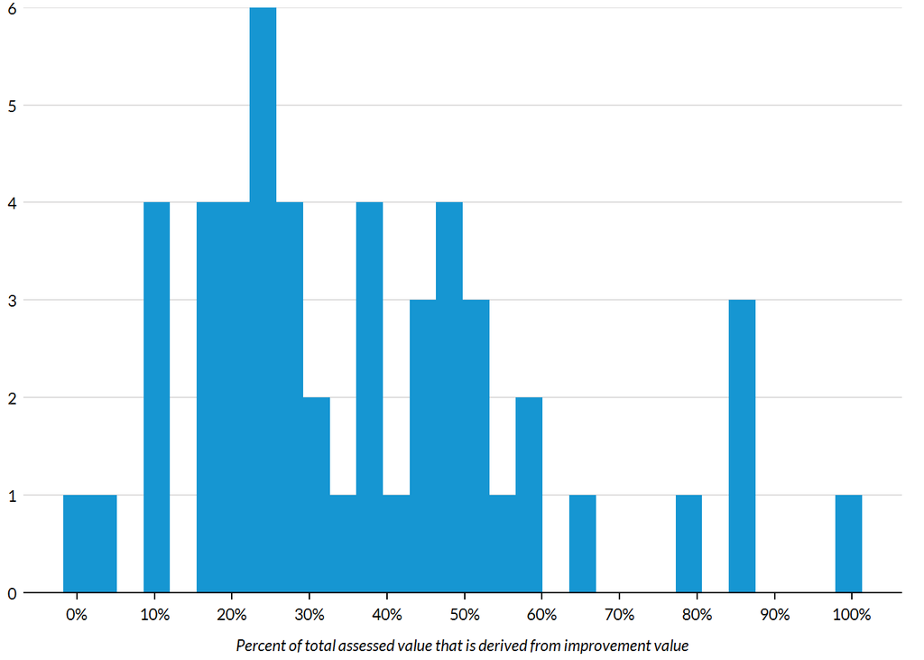

We can recategorize these observations as “vacant with structure”, and will not include these in the calculation. We can also make a flag for missing coordinates.

```r
jur2 <- jur1 %>%
  mutate(category = ifelse(assessedimprovementvalue > 0 &
                           !is.na(assessedimprovementvalue) &
                             category == "vacant",
                           "vacant with structure",
                           category))

count(jur2, category)
```

```
## # A tibble: 5 x 2
##   category                  n
##   <chr>                 <int>
## 1 mf                     2619
## 2 other                  1237
## 3 sf                    35915
## 4 vacant                 2224
## 5 vacant with structure    51
```

```r
jur2 <- jur2 %>%
  mutate(missing_coord = ifelse(is.na(lat) | is.na(long),
                                1,
                                0))
```

### Missing zoning variables

To determine zoning codes for addresses that have a missing zoning designation or multiple zoning designations, we will use a spatial join to the county’s zoning layer.

Read in zoning layer, set CRS

```r
zdir <- paste0("L:/Libraries/RegHsg/Maps/",
               filepath,
               "-zoning-map")
zfile <- str_sub(list.files(zdir), end = -5) %>% unique()

zon <- read_sf(dsn = zdir,
               layer = zfile)

st_geometry(zon)
```

```
## Geometry set for 614 features
## geometry type:  POLYGON
## dimension:      XY
## bbox:           xmin: 11860790 ymin: 6987492 xmax: 11900920 ymax: 7026257
## epsg (SRID):    NA
## proj4string:    +proj=lcc +lat_1=38.03333333333333 +lat_2=39.2 +lat_0=37.66666666666666 +lon_0=-78.5 +x_0=3499999.999999999 +y_0=2000000 +datum=NAD83 +units=us-ft +no_defs
## First 5 geometries:
```

```r
zon <- st_transform(zon, crs = 4326)
```

Convert parcel data to SF, set CRS. To convert to SF, we need to use only the observations with non-missing longitude and latitude. We separate these off and recombine after the spatial join.

```r
jursf <- jur2 %>%
  filter(missing_coord == 0) %>%
  st_as_sf(coords = c("long", "lat")) %>%
  st_set_crs(st_crs(zon))
```

Plot to make sure they are overlapping

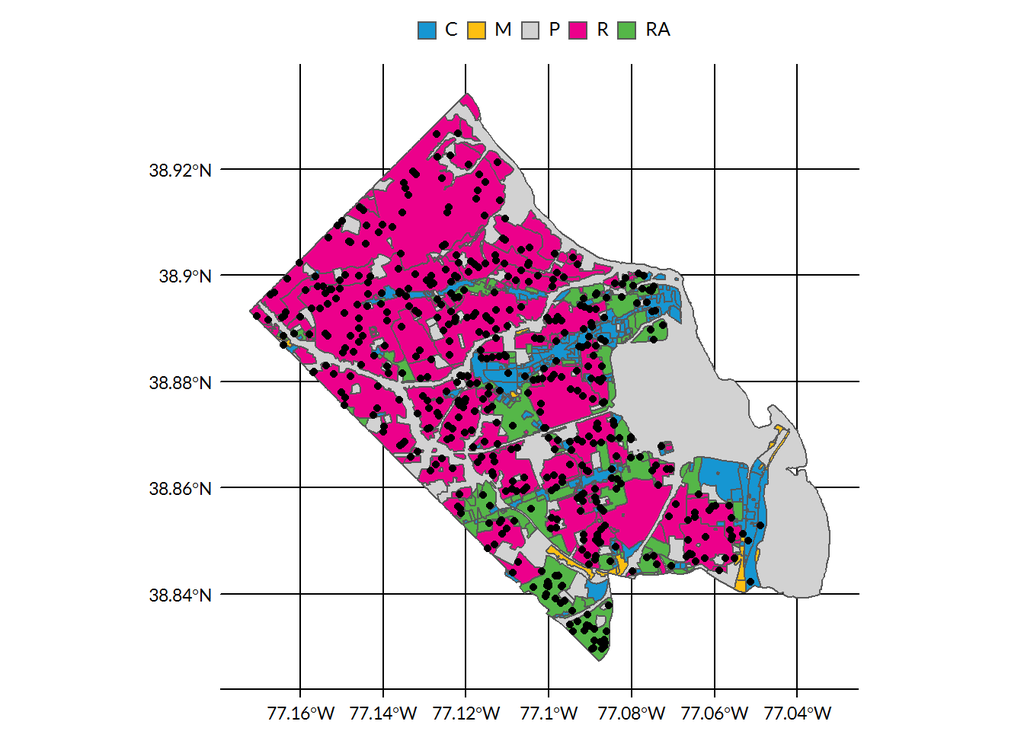

Spatial join

```r
jurjoin <- st_join(jursf, zon, join = st_intersects)
```

After the join, we convert back to a dataframe, for ease of computations.

```r
jur3 <- st_set_geometry(jurjoin, NULL)
```

Count how many observations did not join. This will throw an error if more than 5% did not match- in this case, check the underlying shapefiles for compatability.

```r
paste0(sum(is.na(jur3$ZN_DESIG)), " observations didn't join- ",
      round(sum(is.na(jur3$ZN_DESIG)) / nrow(jur3) * 100, 2), "%")
```

```
## [1] "17 observations didn't join- 0.04%"
```

```r
if (sum(is.na(jur3$ZN_DESIG)) / nrow(jur3) > .05) {
  stop("More than 5% of observations could not be spatially joined.")
}
```

Test how many have different results from the Black Knight zoning variable.

```r
jur3 %>%
  group_by(is.na(zoning)) %>%
  count(zoning == ZN_DESIG)
```

```
## # A tibble: 4 x 3
## # Groups:   is.na(zoning) [2]
##   `is.na(zoning)` `zoning == ZN_DESIG`     n
##   <lgl>           <lgl>                <int>
## 1 FALSE           FALSE                 1249
## 2 FALSE           TRUE                 40292
## 3 FALSE           NA                      17
## 4 TRUE            NA                     176
```

Take a closer look how many and what percent are different “just because”- not because they didn’t merge, have missing values, or have duplicate values.

```r
jur3 %>%
  filter(!is.na(zoning),
         !is.na(ZN_DESIG),
         str_detect(zoning, "/") == FALSE) %>%
  mutate(different_flag = ifelse(zoning != ZN_DESIG,
                                 1,
                                 0)) %>%
  summarize(different = sum(different_flag, na.rm = TRUE)) %>%
  mutate(percent_different = paste0(round(different / nrow(jur3) *100, 2), "%"))
```

```
## # A tibble: 1 x 2
##   different percent_different
##       <dbl> <chr>
## 1       645 1.55%
```

Many are different because the Black Knight zoning has two zoning codes, separated by a slash. We can test how many of these instances have the spatially joined zoning designation in the Black Knight zoning variable.

```r
jur3 %>%
  filter(str_detect(zoning, "/")) %>%
  count(str_detect(zoning, ZN_DESIG))
```

```
## # A tibble: 2 x 2
##   `str_detect(zoning, ZN_DESIG)`     n
##   <lgl>                          <int>
## 1 FALSE                             66
## 2 TRUE                             538
```

If the zoning is missing OR the zoning contains a slash and the spatially joined zoning designation is one of the dual descriptions, we replace with spatial joined zoning. Archive Black Knight zoning variable for future reference.

```r
jur4 <- jur3 %>%
  mutate(zoning_bk = zoning,
         zoning = ifelse(is.na(zoning),
                         ZN_DESIG,
                         zoning),
         zoning = ifelse(str_detect(zoning, "/") == TRUE &
                           str_detect(zoning_bk, ZN_DESIG) == TRUE,
                         ZN_DESIG,
                         zoning)) %>%
  select(-c(OBJECTID, ZONECODE, LABEL, SYMBOL, ZN_DESIG_6, GZDC))
```

Recombine with observations with missing coordinates, check that number of rows is the same.

```r
jurtotal <- jur2 %>%
  filter(is.na(lat) | is.na(long)) %>%
  mutate(zoning_bk = zoning) %>%
  bind_rows(jur4)

stopifnot(nrow(jurtotal) == nrow(jur))
```

### Dual zoning codes

The last step is to identify a zoning designation for observations that either…

1. Have missing coordinates and have a dual zoning designation from Black Knight
2. Have a dual zoning designation from Black Knight but one of the zoning codes does not match the results from the spatial join.

First, isolate these observations and separate each zoning code into its own observation. **NOTE:** For Arlington, the max codes was 4- adjust the `into =` argument accordingly for each jurisdiction.

```r
dual <- jurtotal %>%
  filter((str_detect(zoning, "/") == TRUE &
            str_detect(zoning_bk, ZN_DESIG) == FALSE) |
          (str_detect(zoning, "/") == TRUE &
           missing_coord == TRUE)) %>%
  separate(zoning_bk,
           into = c("z1", "z2", "z3", "z4"),
           sep = "/",
           remove = FALSE)
```

Get rid of values that are NOT in the cleaned zoning code data. These codes do not allow for residential development.

```r
dual <- dual %>%
  mutate_at(vars(z1, z2, z3, z4),
            ~ ifelse(!. %in% zoningcode1$zoning_code,
                     NA,
                     .))
```

Convert to long so that we can list the zoning variables- then `group_by` the parcel ID, and check the lengths to make sure that is unique, so that we can merge results back in.

```r
long <- dual %>%
  gather(key = "position", value = "code", -c(1:47, 52))

dual2 <- long %>%
  group_by(assessorsparcelnumberapnpin) %>%
  summarize(zlist = list(code))

stopifnot(nrow(dual) == nrow(dual2))
```

If there is only one code left after getting rid of the ones that don’t allow for residential codes, take that code.

```r
dual2 <- dual2 %>%
  mutate(count = map(zlist, ~ sum(!is.na(.)))) %>%
  mutate(zoning_true = ifelse(count == 1,
                              map(zlist, max, na.rm = TRUE),
                              ""))
```

```r
dual2 <- dual2 %>%
  mutate(res = map(zlist, ~ substr(., 1, 1)),
         reslist = map(zlist, ~ .[str_detect(., "R")]),
         num1 = map(zlist, parse_number),
         num2 = map(num1, abs),
         num3 = map(num2, ~ round(min(., na.rm = TRUE), 0)),
         num4 = as.character(num3),
         r_count = map(res, ~ sum(. == "R", na.rm = TRUE)),
         zoning_true = ifelse(r_count == 1 & zoning_true == "",
                              map(zlist, ~ max(.[str_detect(., "R")],
                                               na.rm = TRUE)),
                              zoning_true),
         zoning_true = ifelse(r_count == 2,
                              map2(reslist, num4, ~ max(.[str_detect(.x, c(.y, "R"))],
                                                      na.rm = TRUE)),
                              zoning_true))
```

The remaining codes only allow for one dwelling districts, so we will just take the first code.

```r
dual3 <- dual2 %>%
  mutate(zoning_true = ifelse(zoning_true == "",
                       map(zlist, 1),
                       zoning_true),
         zoning_true = as.character(zoning_true))

stopifnot(sum(is.na(dual3$zoning_true)) == 0)
```

Look at a few observations to confirm.

```r
dual3 %>%
  sample_n(10) %>%
  select(parcel = assessorsparcelnumberapnpin, zlist, zoning_true) %>%
  knitr::kable()
```

| parcel | zlist | zoning_true |
| --- | --- | --- |
| 26-001-157 | c(“R-5”, “C-2”, NA, NA) | R-5 |
| 26-001-141 | c(“R-5”, “C-2”, NA, NA) | R-5 |
| 36-038-002 | c(“R-6”, “R-5”, NA, NA) | R-5 |
| 26-001-133 | c(“R-5”, “C-2”, NA, NA) | R-5 |
| 13-002-010 | c(“S-3A”, “R2-7”, “RA8-18”, NA) | RA8-18 |
| 26-001-139 | c(“R-5”, “C-2”, NA, NA) | R-5 |
| 16-010-031 | c(“S-3A”, “R-5”, NA, NA) | R-5 |
| 14-060-084 | c(“RA8-18”, NA, NA, NA) | RA8-18 |
| 26-001-123 | c(“R-5”, “C-2”, NA, NA) | R-5 |
| 26-001-126 | c(“R-5”, “C-2”, NA, NA) | R-5 |

Select only the clean zoning variable, merge back into main dataset, and replace zoning variable. Initial Black Knight variable will still be archived.

```r
jurfinal <-jurtotal %>%
  left_join(select(dual3,
                   assessorsparcelnumberapnpin, zoning = zoning_true),
            by = "assessorsparcelnumberapnpin") %>%
  rename(zoning= zoning.x) %>%
  mutate(zoning = ifelse(!is.na(zoning.y),
                         zoning.y,
                         zoning)) %>%
  select(-zoning.y)
```

Save the final parcel data so it can be used for the special exceptions (this is only required for Arlington county).

```r
saveRDS(jurfinal, "L:/Libraries/RegHsg/Data/arlington/arlington-lots.Rdata")
saveRDS(zoningcode1, "L:/Libraries/RegHsg/Data/arlington/arlington-clean-zoning-code.Rdata")
```

** Switch to `04_vacant-lots-2-arlington-se.Rmd` **